# Analysis_notebook

Loading libraries

```r
library(tidyverse)
library(dplyr)
library(ggplot2)
library(tidyr)
library(stringr)
library(janitor)
```

Loading and Viewing the first 6 rows of the table

```r
activity_sleep_weight <- read_csv("./Data/cleaned_data/activity_sleep_weight_daily_joined_08_05_2022_v02.csv")
head(activity_sleep_weight)
```

| id | activity_date | total_steps | total_distance | sedentary_minutes | calories | total_sleep_records | total_minutes_asleep | total_time_in_bed | total_hours_asleep | total_hours_in_bed | weight_kg | weight_pounds | bmi | is_manual_report |
| --- | --- | --- | --- | --- | --- | --- | --- | --- | --- | --- | --- | --- | --- | --- |
| 1503960366 | 2016-04-12 | 13162 | 8.50 | 728 | 1985 | 1 | 327 | 346 | 5.45 | 5.77 | NA | NA | NA | NA |
| 1503960366 | 2016-04-13 | 10735 | 6.97 | 776 | 1797 | 2 | 384 | 407 | 6.40 | 6.78 | NA | NA | NA | NA |
| 1503960366 | 2016-04-15 | 9762 | 6.28 | 726 | 1745 | 1 | 412 | 442 | 6.87 | 7.37 | NA | NA | NA | NA |
| 1503960366 | 2016-04-16 | 12669 | 8.16 | 773 | 1863 | 2 | 340 | 367 | 5.67 | 6.12 | NA | NA | NA | NA |
| 1503960366 | 2016-04-17 | 9705 | 6.48 | 539 | 1728 | 1 | 700 | 712 | 11.67 | 11.87 | NA | NA | NA | NA |
| 1503960366 | 2016-04-19 | 15506 | 9.88 | 775 | 2035 | 1 | 304 | 320 | 5.07 | 5.33 | NA | NA | NA | NA |

checking table structure to know * number of columns and rows * datatype for each variable (column)

```r
str(activity_sleep_weight)
```

```
spec_tbl_df [410 x 15] (S3: spec_tbl_df/tbl_df/tbl/data.frame)
 $ id                  : num [1:410] 1.5e+09 1.5e+09 1.5e+09 1.5e+09 1.5e+09 ...
 $ activity_date       : Date[1:410], format: "2016-04-12" ...
 $ total_steps         : num [1:410] 13162 10735 9762 12669 9705 ...
 $ total_distance      : num [1:410] 8.5 6.97 6.28 8.16 6.48 ...
 $ sedentary_minutes   : num [1:410] 728 776 726 773 539 775 818 838 732 709 ...
 $ calories            : num [1:410] 1985 1797 1745 1863 1728 ...
 $ total_sleep_records : num [1:410] 1 2 1 2 1 1 1 1 1 1 ...
 $ total_minutes_asleep: num [1:410] 327 384 412 340 700 304 360 325 361 430 ...
 $ total_time_in_bed   : num [1:410] 346 407 442 367 712 320 377 364 384 449 ...
 $ total_hours_asleep  : num [1:410] 5.45 6.4 6.87 5.67 11.67 ...
 $ total_hours_in_bed  : num [1:410] 5.77 6.78 7.37 6.12 11.87 ...
 $ weight_kg           : num [1:410] NA NA NA NA NA NA NA NA NA NA ...
 $ weight_pounds       : num [1:410] NA NA NA NA NA NA NA NA NA NA ...
 $ bmi                 : num [1:410] NA NA NA NA NA NA NA NA NA NA ...
 $ is_manual_report    : logi [1:410] NA NA NA NA NA NA ...
 - attr(*, "spec")=
  .. cols(
  ..   id = col_double(),
  ..   activity_date = col_date(format = ""),
  ..   total_steps = col_double(),
  ..   total_distance = col_double(),
  ..   sedentary_minutes = col_double(),
  ..   calories = col_double(),
  ..   total_sleep_records = col_double(),
  ..   total_minutes_asleep = col_double(),
  ..   total_time_in_bed = col_double(),
  ..   total_hours_asleep = col_double(),
  ..   total_hours_in_bed = col_double(),
  ..   weight_kg = col_double(),
  ..   weight_pounds = col_double(),
  ..   bmi = col_double(),
  ..   is_manual_report = col_logical()
  .. )
 - attr(*, "problems")=<externalptr>
```

Checking summary statistics

```r
summary(activity_sleep_weight)
```

```
       id            activity_date         total_steps
 Min.   :1.504e+09   Min.   :2016-04-12   Min.   :   17
 1st Qu.:3.977e+09   1st Qu.:2016-04-19   1st Qu.: 5189
 Median :4.703e+09   Median :2016-04-27   Median : 8913
 Mean   :4.995e+09   Mean   :2016-04-26   Mean   : 8515
 3rd Qu.:6.962e+09   3rd Qu.:2016-05-04   3rd Qu.:11370
 Max.   :8.792e+09   Max.   :2016-05-12   Max.   :22770

 total_distance   sedentary_minutes    calories
 Min.   : 0.010   Min.   :   0.0    Min.   : 257
 1st Qu.: 3.592   1st Qu.: 631.2    1st Qu.:1841
 Median : 6.270   Median : 717.0    Median :2207
 Mean   : 6.012   Mean   : 712.1    Mean   :2389
 3rd Qu.: 8.005   3rd Qu.: 782.8    3rd Qu.:2920
 Max.   :17.540   Max.   :1265.0    Max.   :4900

 total_sleep_records total_minutes_asleep total_time_in_bed
 Min.   :1.00        Min.   : 58.0        Min.   : 61.0
 1st Qu.:1.00        1st Qu.:361.0        1st Qu.:403.8
 Median :1.00        Median :432.5        Median :463.0
 Mean   :1.12        Mean   :419.2        Mean   :458.5
 3rd Qu.:1.00        3rd Qu.:490.0        3rd Qu.:526.0
 Max.   :3.00        Max.   :796.0        Max.   :961.0

 total_hours_asleep total_hours_in_bed   weight_kg
 Min.   : 0.970     Min.   : 1.020     Min.   : 52.60
 1st Qu.: 6.020     1st Qu.: 6.732     1st Qu.: 61.20
 Median : 7.210     Median : 7.720     Median : 61.50
 Mean   : 6.987     Mean   : 7.641     Mean   : 64.17
 3rd Qu.: 8.170     3rd Qu.: 8.770     3rd Qu.: 61.90
 Max.   :13.270     Max.   :16.020     Max.   :133.50
                                       NA's   :375
 weight_pounds        bmi        is_manual_report
 Min.   :116.0   Min.   :22.65   Mode :logical
 1st Qu.:134.9   1st Qu.:23.89   FALSE:2
 Median :135.6   Median :24.00   TRUE :33
 Mean   :141.5   Mean   :24.83   NA's :375
 3rd Qu.:136.5   3rd Qu.:24.17
 Max.   :294.3   Max.   :47.54
 NA's   :375     NA's   :375
```

Total number of users in the fitbit dataset are 34 users, however ONLY 24 users have records and 10 users have empty records (all data is 0) so users that have at least one not empty record are considered Active users users that have empty records are considered Dormant users

```r
active_dormant <- data.frame(users_activity = c("Active", "Dormant"),
                             users_count = c(24,10),
                             users_percent = c(round((24/34)*100),round((10/34)*100)),
                             users_percent_lbl = c(str_c(round((24/34)*100),"%"),str_c(round((10/34)*100),"%")))

active_dormant
```

| users_activity | users_count | users_percent | users_percent_lbl |
| --- | --- | --- | --- |
| Active | 24 | 71 | 71% |
| Dormant | 10 | 29 | 29% |

Creating a summary table

```r
table_sumarry <- activity_sleep_weight %>% group_by(id) %>%
  summarise(days_count = n(), avg_steps = mean(total_steps), avg_sleep = mean(total_hours_asleep))

table_sumarry
```

| id | days_count | avg_steps | avg_sleep |
| --- | --- | --- | --- |
| 1503960366 | 25 | 12405.680 | 6.005600 |
| 1644430081 | 4 | 7967.750 | 4.900000 |
| 1844505072 | 3 | 3477.000 | 10.863333 |
| 1927972279 | 5 | 1490.000 | 6.950000 |
| 2026352035 | 28 | 5618.679 | 8.436429 |
| 2320127002 | 1 | 5079.000 | 1.020000 |
| 2347167796 | 15 | 8533.200 | 7.447333 |
| 3977333714 | 28 | 11218.000 | 4.895000 |
| 4020332650 | 8 | 6596.750 | 5.825000 |
| 4319703577 | 26 | 7125.423 | 7.944231 |

[output cut: 14 more lines]

Creating dataframe that contains data about Active users and how many days they use their devices.

```r
users_percent <-data.frame(days_range =c("1 Week","2 Weeks", "3 Weeks","4 Weeks"), user_count= c(0,0,0,0))
```

initialize the counters

```r
counter_1_wk <- 0
counter_2_wks <- 0
counter_3_wks <- 0
counter_4_wks <- 0
```

for loop to count number of users based on the number of days they used the device (table_sumarry) and associating it with the corresponding days range “Number of users that used the device for the specified days range”

```r
for (i in table_sumarry$days_count){

  if (1<= i & i <= 7){

    users_percent[1,]['days_range'] <- "1-7"
    counter_1_wk <- counter_1_wk+ 1
    users_percent[1,]['user_count'] <- counter_1_wk
  }

  else if (8 <= i & i <= 14){
    users_percent[2,]['days_range'] <- "8-14"
    counter_2_wks <- counter_2_wks + 1
    users_percent[2,]['user_count'] <- counter_2_wks
  }

  else if (15 <= i & i <= 21){
    users_percent[3,]['days_range'] <- "15-21"
    counter_3_wks <- counter_3_wks + 1
    users_percent[3,]['user_count'] <- counter_3_wks
  }
  else if (22 <= i & i <= 31){
    users_percent[4,]['days_range'] <- "22-31"
    counter_4_wks <- counter_4_wks + 1
    users_percent[4,]['user_count'] <- counter_4_wks
  }

}
```

viewing the new table

```r
users_percent
```

| days_range | user_count |
| --- | --- |
| 1-7 | 8 |
| 8-14 | 1 |
| 15-21 | 3 |
| 22-31 | 12 |

adding new columns  
**user_percentage** to calculate the percentage of users *user_percentage_lbl* to add *%* symbol to be the label column (to be used in the charts)

```r
users_percent$user_percentage <- round((users_percent$user_count/24)*100,1)
users_percent$user_percentage_lbl <- str_c(users_percent$user_percentage,"%")
users_percent
```

| days_range | user_count | user_percentage | user_percentage_lbl |
| --- | --- | --- | --- |
| 1-7 | 8 | 33.3 | 33.3% |
| 8-14 | 1 | 4.2 | 4.2% |
| 15-21 | 3 | 12.5 | 12.5% |
| 22-31 | 12 | 50.0 | 50% |

order *user_percentage* DESC

```r
users_percent <- users_percent[order(users_percent$user_percentage, decreasing = TRUE),]
users_percent
```

|  | days_range | user_count | user_percentage | user_percentage_lbl |
| --- | --- | --- | --- | --- |
| 4 | 22-31 | 12 | 50.0 | 50% |
| 1 | 1-7 | 8 | 33.3 | 33.3% |
| 3 | 15-21 | 3 | 12.5 | 12.5% |
| 2 | 8-14 | 1 | 4.2 | 4.2% |

creating bar plot to show Active users in the specified days range

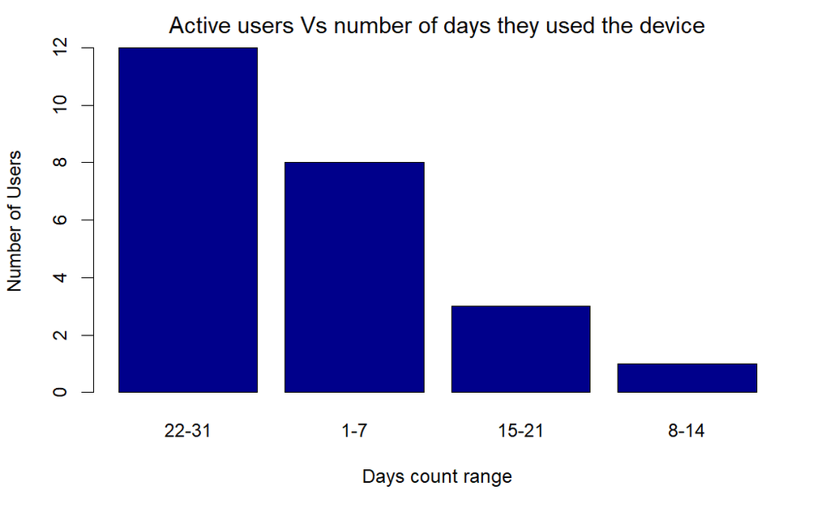

```r
barplot(users_percent$user_count, names.arg = users_percent$days_range,
        xlab = "Days count range", ylab = "Number of Users",
        col = "darkblue", main = "Active users Vs number of days they used the device",
        font.main = 1 )
```

creating pie plot to show the percentage of users and how many days they used the device

[output not shown]

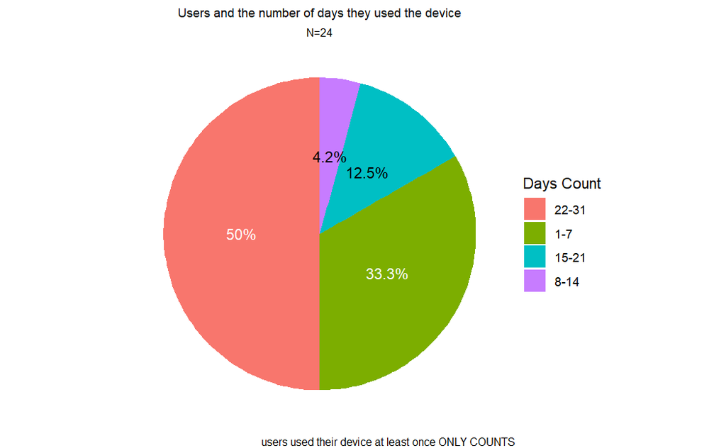

```r
ggplot(users_percent, aes(x=1, y = user_percentage, fill= fct_inorder(days_range) )) +
  geom_col() +
  geom_text(aes(label= user_percentage_lbl),
            position= position_stack(vjust = .5),
            color = c("white","white",1,1)) +
  labs(title = "Users and the number of days they used the device",
       subtitle = "N=24",
       caption = "users used their device at least once ONLY COUNTS")+
  scale_fill_viridis_d()+
  scale_fill_discrete(name= "Days Count")+
  coord_polar(theta = "y")+
  theme_void() +
  theme( plot.title = element_text(hjust = .5, size = 9 ),
    plot.subtitle = element_text(hjust = 0.5, size = 8),
    plot.caption = element_text(hjust = 1, size = 8))
```

number of active users per day

```r
users_per_day <- activity_sleep_weight %>%
  group_by(activity_date) %>%
  summarise(users_count = n())

users_per_day
```

| activity_date | users_count |
| --- | --- |
| 2016-04-12 | 13 |
| 2016-04-13 | 14 |
| 2016-04-14 | 13 |
| 2016-04-15 | 17 |
| 2016-04-16 | 14 |
| 2016-04-17 | 12 |
| 2016-04-18 | 10 |
| 2016-04-19 | 14 |
| 2016-04-20 | 15 |
| 2016-04-21 | 15 |

[output cut: 21 more lines]

```r
NA
```

creating line chart to show how many users use the device per day

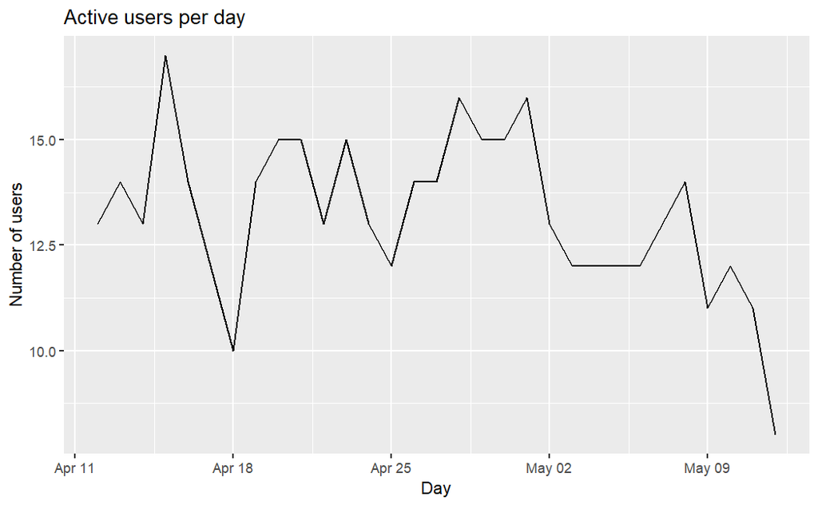

```r
ggplot(data = users_per_day, aes(x= activity_date, y = users_count)) +
  geom_line()+
  ggtitle("Active users per day")+
  xlab("Day")+
  ylab("Number of users")
```

Note: We need more data to confirm patterns

Checking the distribution of data

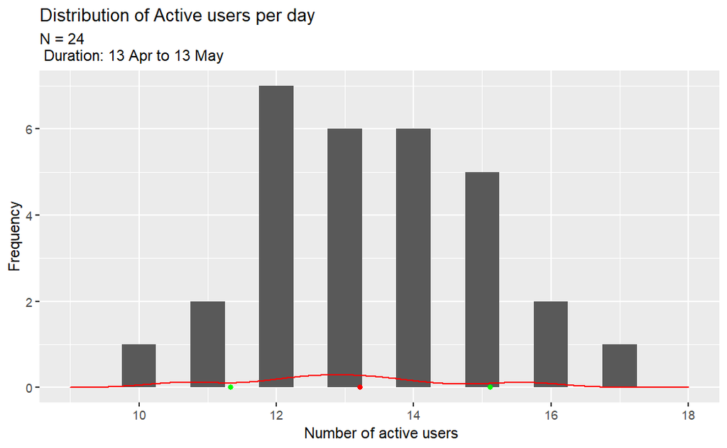

```r
mean_users_count = mean(users_per_day$users_count)
sd_users_count = sd(users_per_day$users_count)

x__ = rnorm(31, mean = mean_users_count, sd = sd_users_count)

ggplot(data = users_per_day) +
  geom_histogram(aes(x= as.integer(users_count)), binwidth = .5)+
  geom_density(aes(x = x__ ), colour = "red", show.legend = FALSE)+
  geom_point(aes(x = mean_users_count, y = 0 ), colour = "red")+
  geom_point(aes(x = mean_users_count + sd_users_count, y = 0), colour = "green")+
  geom_point(aes(x = mean_users_count - sd_users_count, y = 0), colour = "green")+
  xlim(9,18)+
  xlab(" Number of active users")+
  ylab("Frequency")+
  ggtitle("Distribution of Active users per day",
          subtitle = "N = 24 \n Duration: 13 Apr to 13 May")
```

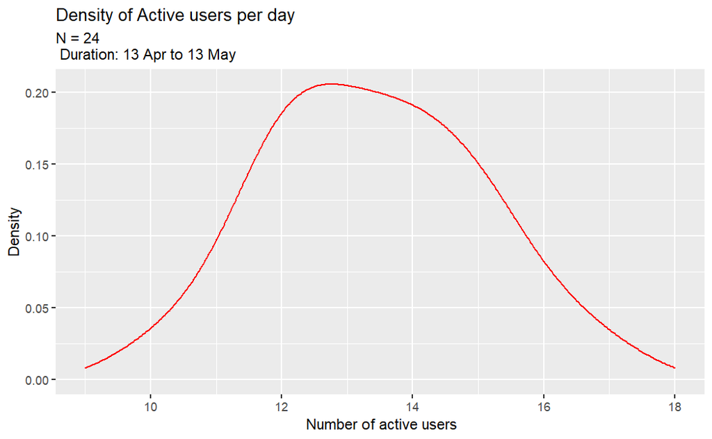

```r
ggplot(data = users_per_day) +
  geom_density(aes(x = as.integer(users_count) ), colour = "red", show.legend = FALSE)+
  xlim(9,18)+
  xlab(" Number of active users")+
  ylab("Density")+
  ggtitle("Density of Active users per day",
          subtitle = "N = 24 \n Duration: 13 Apr to 13 May")
```

according to the density plot, the number of active users per day is normally distributed (bell shaped curve)

we can proceed to check if there is correlation between **weekdays** and **number of Active users**

adding new column weekday and converting the weekday column to be a factor with predefined levels then order the table be weekdays starting from Monday

```r
activity_sleep_weight$weekday <- weekdays(activity_sleep_weight$activity_date)
activity_sleep_weight$weekday <- factor(activity_sleep_weight$weekday, levels = c("Monday",
    "Tuesday", "Wednesday", "Thursday", "Friday", "Saturday","Sunday"))

activity_sleep_weight_orderd <- activity_sleep_weight[order(activity_sleep_weight$weekday),]
activity_sleep_weight_orderd
```

| id | activity_date | total_steps | total_distance | sedentary_minutes | calories | total_sleep_records | total_minutes_asleep | total_time_in_bed | total_hours_asleep | total_hours_in_bed | weight_kg | weight_pounds | bmi | is_manual_report | weekday |
| --- | --- | --- | --- | --- | --- | --- | --- | --- | --- | --- | --- | --- | --- | --- | --- |
| 1503960366 | 2016-04-25 | 15355 | 9.80 | 814 | 2013 | 1 | 277 | 323 | 4.62 | 5.38 | NA | NA | NA | NA | Monday |
| 1503960366 | 2016-05-02 | 14727 | 9.71 | 798 | 2004 | 1 | 277 | 309 | 4.62 | 5.15 | 52.6 | 115.9632 | 22.65 | TRUE | Monday |
| 1503960366 | 2016-05-09 | 12022 | 7.72 | 835 | 1819 | 1 | 338 | 342 | 5.63 | 5.70 | NA | NA | NA | NA | Monday |
| 1644430081 | 2016-05-02 | 3758 | 2.73 | 682 | 2580 | 1 | 796 | 961 | 13.27 | 16.02 | NA | NA | NA | NA | Monday |
| 2026352035 | 2016-04-25 | 6017 | 3.73 | 821 | 1576 | 1 | 506 | 531 | 8.43 | 8.85 | NA | NA | NA | NA | Monday |
| 2026352035 | 2016-05-02 | 7018 | 4.35 | 716 | 1690 | 1 | 511 | 543 | 8.52 | 9.05 | NA | NA | NA | NA | Monday |
| 2026352035 | 2016-05-09 | 10685 | 6.62 | 543 | 1869 | 1 | 531 | 556 | 8.85 | 9.27 | NA | NA | NA | NA | Monday |
| 2347167796 | 2016-04-18 | 8247 | 5.45 | 678 | 1944 | 1 | 500 | 557 | 8.33 | 9.28 | NA | NA | NA | NA | Monday |
| 2347167796 | 2016-04-25 | 9482 | 6.38 | 653 | 2095 | 1 | 433 | 471 | 7.22 | 7.85 | NA | NA | NA | NA | Monday |
| 3977333714 | 2016-04-18 | 11663 | 7.80 | 605 | 1584 | 2 | 412 | 522 | 6.87 | 8.70 | NA | NA | NA | NA | Monday |

[output cut: 400 more lines]

```r
weekdays_df <- activity_sleep_weight_orderd %>%
  group_by(activity_date,weekday) %>% summarise(user_count= n())
weekdays_df
```

| activity_date | weekday | user_count |
| --- | --- | --- |
| 2016-04-12 | Tuesday | 13 |
| 2016-04-13 | Wednesday | 14 |
| 2016-04-14 | Thursday | 13 |
| 2016-04-15 | Friday | 17 |
| 2016-04-16 | Saturday | 14 |
| 2016-04-17 | Sunday | 12 |
| 2016-04-18 | Monday | 10 |
| 2016-04-19 | Tuesday | 14 |
| 2016-04-20 | Wednesday | 15 |
| 2016-04-21 | Thursday | 15 |

[output cut: 21 more lines]

boxplot

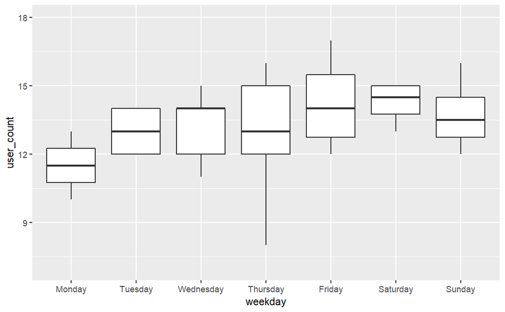

```r
ggplot(data=weekdays_df)+
  geom_boxplot(aes(x=weekday,y = user_count),
               outlier.colour="red",
               outlier.shape=8,
               outlier.size=4)+
  ylim(7,18)
```

according to the boxplot

- Tuesday and Thursday have the same median but number of users is more variable on Thursday. (sometimes it is high and sometimes it is very low)
- Wednesday and Friday have the same median but number of users is more variable on Friday.
- Monday has the lowest median and it is less variable than other workdays (the least number of Active users is on Monday) and there is notable difference between the number of users on Monday and any other day
- Saturday has the highest median but the number of users is the least variable (number of users on Sat differ greatly (higher) than Tuesday and Wednesday)
- Sunday has lower median than Saturday but the number of users is more variable

in conclusion: the number of users start increasing from Tuesday to Friday then on Saturday it the is highest and mostly stable (not variable) also on Sunday it start decreasing until it reaches the lowest number of users by Monday

** as the data is normally distributed we can test the following hypothesis

H: some days have greater number of users than others (number of users is associated with weekdays)

H0: There is no association between number of Active users and weekdays.

due to the small sample size we need to combine some days in groups

labeling Tuesday-Friday as Tue_Fri, Saturday& Sunday as Sat_Sun AND Monday will be on it`s own

```r
weekdays_df$day_type <- "W"
weekdays_df
```

| activity_date | weekday | user_count | day_type |
| --- | --- | --- | --- |
| 2016-04-12 | Tuesday | 13 | W |
| 2016-04-13 | Wednesday | 14 | W |
| 2016-04-14 | Thursday | 13 | W |
| 2016-04-15 | Friday | 17 | W |
| 2016-04-16 | Saturday | 14 | W |
| 2016-04-17 | Sunday | 12 | W |
| 2016-04-18 | Monday | 10 | W |
| 2016-04-19 | Tuesday | 14 | W |
| 2016-04-20 | Wednesday | 15 | W |
| 2016-04-21 | Thursday | 15 | W |

[output cut: 21 more lines]

```r
workday <- c("Monday",
    "Tuesday", "Wednesday", "Thursday", "Friday")
weekend <- c("Saturday","Sunday")

#(i in table_sumarry$days_count)
#users_percent[1,]['days_range'] <- "1-7"

for (i in 1:31){
  #print(i)
  if (weekdays_df$weekday[i] %in% workday){
    print(i)
    weekdays_df[i,]["day_type"] <- "workday"
  }
  if (weekdays_df$weekday[i] %in% weekend){
    weekdays_df[i,]["day_type"] <- "weekend"
  }
  i = i + 1
}
```

```
[1] 1
[1] 2
[1] 3
[1] 4
[1] 7
[1] 8
[1] 9
[1] 10
[1] 11
[1] 14
[1] 15
[1] 16
[1] 17
[1] 18
[1] 21
[1] 22
[1] 23
[1] 24
[1] 25
[1] 28
[1] 29
[1] 30
[1] 31
```

```r
weekdays_df
```

| activity_date | weekday | user_count | day_type |
| --- | --- | --- | --- |
| 2016-04-12 | Tuesday | 13 | workday |
| 2016-04-13 | Wednesday | 14 | workday |
| 2016-04-14 | Thursday | 13 | workday |
| 2016-04-15 | Friday | 17 | workday |
| 2016-04-16 | Saturday | 14 | weekend |
| 2016-04-17 | Sunday | 12 | weekend |
| 2016-04-18 | Monday | 10 | workday |
| 2016-04-19 | Tuesday | 14 | workday |
| 2016-04-20 | Wednesday | 15 | workday |
| 2016-04-21 | Thursday | 15 | workday |

[output cut: 21 more lines]

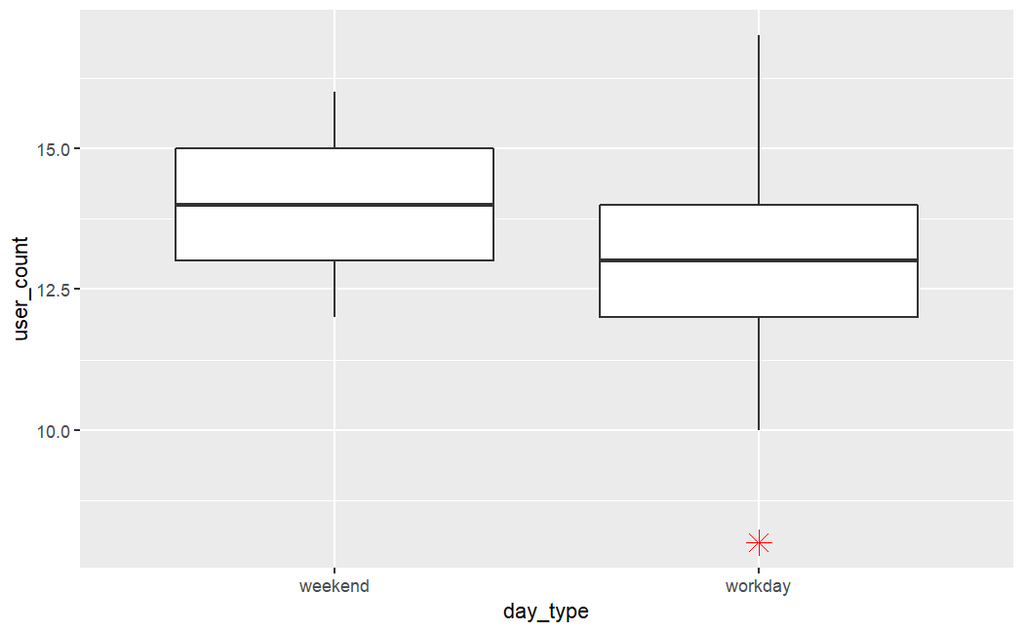

```r
ggplot(data=weekdays_df)+
  geom_boxplot(aes(x=day_type,y = user_count),
               outlier.colour="red",
               outlier.shape=8,
               outlier.size=4)
```

```r
  #ylim(7,18)
```

```r
weekdays_df$day_type <- "W"
weekdays_df
```

| activity_date | weekday | user_count | day_type |
| --- | --- | --- | --- |
| 2016-04-12 | Tuesday | 13 | W |
| 2016-04-13 | Wednesday | 14 | W |
| 2016-04-14 | Thursday | 13 | W |
| 2016-04-15 | Friday | 17 | W |
| 2016-04-16 | Saturday | 14 | W |
| 2016-04-17 | Sunday | 12 | W |
| 2016-04-18 | Monday | 10 | W |
| 2016-04-19 | Tuesday | 14 | W |
| 2016-04-20 | Wednesday | 15 | W |
| 2016-04-21 | Thursday | 15 | W |

[output cut: 21 more lines]

```r
workday <- c("Monday",
    "Tuesday", "Wednesday", "Thursday", "Friday")
weekend <- c("Saturday","Sunday")

#(i in table_sumarry$days_count)
#users_percent[1,]['days_range'] <- "1-7"

for (i in 1:31){
  #print(i)
  if (weekdays_df$weekday[i] %in% workday){
    print(i)
    weekdays_df[i,]["day_type"] <- "workday"
  }
  if (weekdays_df$weekday[i] %in% weekend){
    weekdays_df[i,]["day_type"] <- "weekend"
  }
  i = i + 1
}
```

```
[1] 1
[1] 2
[1] 3
[1] 4
[1] 7
[1] 8
[1] 9
[1] 10
[1] 11
[1] 14
[1] 15
[1] 16
[1] 17
[1] 18
[1] 21
[1] 22
[1] 23
[1] 24
[1] 25
[1] 28
[1] 29
[1] 30
[1] 31
```

```r
weekdays_df_2 <- weekdays_df
weekdays_df_2$day_type <- "W"
weekdays_df_2
```

| activity_date | weekday | user_count | day_type |
| --- | --- | --- | --- |
| 2016-04-12 | Tuesday | 13 | W |
| 2016-04-13 | Wednesday | 14 | W |
| 2016-04-14 | Thursday | 13 | W |
| 2016-04-15 | Friday | 17 | W |
| 2016-04-16 | Saturday | 14 | W |
| 2016-04-17 | Sunday | 12 | W |
| 2016-04-18 | Monday | 10 | W |
| 2016-04-19 | Tuesday | 14 | W |
| 2016-04-20 | Wednesday | 15 | W |
| 2016-04-21 | Thursday | 15 | W |

[output cut: 21 more lines]

```r
Tue_Fri <- c(
    "Tuesday", "Wednesday", "Thursday", "Friday")
Sat_Sun <- c("Saturday","Sunday")


for (i in 1:31){
  #print(i)
  if (weekdays_df_2$weekday[i] %in% Tue_Fri){
    print(i)
    weekdays_df_2[i,]["day_type"] <- "Tue_Fri"
  }
  if (weekdays_df_2$weekday[i] %in% Sat_Sun){
    weekdays_df_2[i,]["day_type"] <- "Sat_Sun"
  }
  if (weekdays_df_2$weekday[i] == "Monday"){
    weekdays_df_2[i,]["day_type"] <- "Monday"
  }
  i = i + 1
}
```

```
[1] 1
[1] 2
[1] 3
[1] 4
[1] 8
[1] 9
[1] 10
[1] 11
[1] 15
[1] 16
[1] 17
[1] 18
[1] 22
[1] 23
[1] 24
[1] 25
[1] 29
[1] 30
[1] 31
```

```r
weekdays_df_2
```

| activity_date | weekday | user_count | day_type |
| --- | --- | --- | --- |
| 2016-04-12 | Tuesday | 13 | Tue_Fri |
| 2016-04-13 | Wednesday | 14 | Tue_Fri |
| 2016-04-14 | Thursday | 13 | Tue_Fri |
| 2016-04-15 | Friday | 17 | Tue_Fri |
| 2016-04-16 | Saturday | 14 | Sat_Sun |
| 2016-04-17 | Sunday | 12 | Sat_Sun |
| 2016-04-18 | Monday | 10 | Monday |
| 2016-04-19 | Tuesday | 14 | Tue_Fri |
| 2016-04-20 | Wednesday | 15 | Tue_Fri |
| 2016-04-21 | Thursday | 15 | Tue_Fri |

[output cut: 21 more lines]

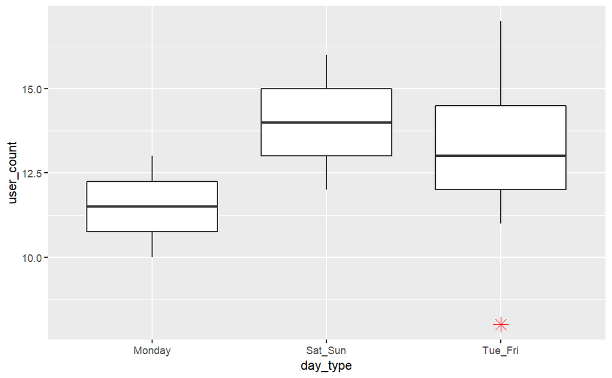

```r
ggplot(data=weekdays_df_2)+
  geom_boxplot(aes(x=day_type,y = user_count),
               outlier.colour="red",
               outlier.shape=8,
               outlier.size=4)
```

```r
  #ylim(7,18)
```

Sat-Sun group has the highest median (hence greater number of users) Tue-Fri group has lower median than Sat-Sun Group however it is more variable and has an outlier

Monday has the lowest median (there is huge difference between number of users on Monday and any other day(the lowest))

In conclusion: more users (consistent) use the device on weekends (Sat-Sun) than workdays (Tue-Fri). the least number of users is on Monday (consistent)

We should apply Mann-Whitney U test To test the hypothesis

```r
weekdays_test_df <- weekdays_df_2 %>%
  select(user_count,day_type)
```

```r
weekdays_test_df <- weekdays_test_df %>%
  subset(select= -activity_date)
```

```r
weekdays_test_df
```

| user_count | day_type |
| --- | --- |
| 13 | Tue_Fri |
| 14 | Tue_Fri |
| 13 | Tue_Fri |
| 17 | Tue_Fri |
| 14 | Sat_Sun |
| 12 | Sat_Sun |
| 10 | Monday |
| 14 | Tue_Fri |
| 15 | Tue_Fri |
| 15 | Tue_Fri |

[output cut: 21 more lines]

```r
weekdays_test_df %>% group_by(day_type) %>%
  summarise(sum=n())
```

| day_type | sum |
| --- | --- |
| Monday | 4 |
| Sat_Sun | 8 |
| Tue_Fri | 19 |

### Step 2

select equal samples

Sample size = 4

and for Tue_Fri group only sample size = 8 and sample size =4

```r
Sat_Sun_subset <- weekdays_test_df %>%
  filter(day_type == "Sat_Sun")

Tue_Fri_subset <- weekdays_test_df %>%
  filter(day_type == "Tue_Fri")

Monday_subset <- weekdays_test_df %>%
  filter(day_type == "Monday")
```

```r
Sat_Sun_subset
```

| user_count | day_type |
| --- | --- |
| 14 | Sat_Sun |
| 12 | Sat_Sun |
| 15 | Sat_Sun |
| 13 | Sat_Sun |
| 15 | Sat_Sun |
| 16 | Sat_Sun |
| 13 | Sat_Sun |
| 14 | Sat_Sun |

```r
Tue_Fri_subset
```

| user_count | day_type |
| --- | --- |
| 13 | Tue_Fri |
| 14 | Tue_Fri |
| 13 | Tue_Fri |
| 17 | Tue_Fri |
| 14 | Tue_Fri |
| 15 | Tue_Fri |
| 15 | Tue_Fri |
| 13 | Tue_Fri |
| 14 | Tue_Fri |
| 14 | Tue_Fri |

[output cut: 9 more lines]

```r
Monday_subset
```

| user_count | day_type |
| --- | --- |
| 10 | Monday |
| 12 | Monday |
| 13 | Monday |
| 11 | Monday |

```r
Sat_Sun_sample <- sample_n(Sat_Sun_subset,4)
```

```r
Sat_Sun_sample <- sample_n(Sat_Sun_subset,4)
Tue_Fri_sample <- sample_n(Tue_Fri_subset,4)
Tue_Fri_sample_8 <- sample_n(Tue_Fri_subset,8)
```

```r
Sat_Sun_sample
```

[output not shown]

```r
Tue_Fri_sample
```

| user_count | day_type |
| --- | --- |
| 8 | Tue_Fri |
| 13 | Tue_Fri |
| 11 | Tue_Fri |
| 13 | Tue_Fri |

```r
Monday_subset
```

| user_count | day_type |
| --- | --- |
| 10 | Monday |
| 12 | Monday |
| 13 | Monday |
| 11 | Monday |

```r
Tue_Fri_sample_8
```

| user_count | day_type |
| --- | --- |
| 12 | Tue_Fri |
| 14 | Tue_Fri |
| 11 | Tue_Fri |
| 14 | Tue_Fri |
| 13 | Tue_Fri |
| 12 | Tue_Fri |
| 12 | Tue_Fri |
| 13 | Tue_Fri |

```r
Sat_Sun_subset
```

| user_count | day_type |
| --- | --- |
| 14 | Sat_Sun |
| 12 | Sat_Sun |
| 15 | Sat_Sun |
| 13 | Sat_Sun |
| 15 | Sat_Sun |
| 16 | Sat_Sun |
| 13 | Sat_Sun |
| 14 | Sat_Sun |

We have 3 groups (Tue-Fri, Sat-Sun, Monday) so there will be multiple tests for each pair.

**Constructing pairs**

adding (Sat-Sun) & (Tue-Fri) in one df Sat_Tue_test_df (sample size=8) adding (Sat-Sun) & (Monday) in one df Sat_Monday_test_df (sample size=4) adding (Tue-Fri) & (Monday) in one df Tue_Monday_test_df (sample size=4)

```r
Sat_Tue_test_df <-rbind(Sat_Sun_subset, Tue_Fri_sample_8)
Sat_Monday_test_df <-rbind(Sat_Sun_sample, Monday_subset)
Tue_Monday_test_df <-rbind(Tue_Fri_sample, Monday_subset)
```

```r
Sat_Monday_test_df <-rbind(Sat_Sun_sample, Monday_subset)
```

```r
Sat_Tue_test_df
```

| user_count | day_type |
| --- | --- |
| 14 | Sat_Sun |
| 12 | Sat_Sun |
| 15 | Sat_Sun |
| 13 | Sat_Sun |
| 15 | Sat_Sun |
| 16 | Sat_Sun |
| 13 | Sat_Sun |
| 14 | Sat_Sun |
| 12 | Tue_Fri |
| 14 | Tue_Fri |

[output cut: 6 more lines]

```r
Sat_Monday_test_df
```

| user_count | day_type |
| --- | --- |
| 13 | Sat_Sun |
| 16 | Sat_Sun |
| 14 | Sat_Sun |
| 12 | Sat_Sun |
| 10 | Monday |
| 12 | Monday |
| 13 | Monday |
| 11 | Monday |

```r
Tue_Monday_test_df
```

| user_count | day_type |
| --- | --- |
| 8 | Tue_Fri |
| 13 | Tue_Fri |
| 11 | Tue_Fri |
| 13 | Tue_Fri |
| 10 | Monday |
| 12 | Monday |
| 13 | Monday |
| 11 | Monday |

Saving the dataframes as csv to be used in the analysis

```r
Sat_Tue_test_df
```

| user_count | day_type |
| --- | --- |
| 14 | Sat_Sun |
| 12 | Sat_Sun |
| 15 | Sat_Sun |
| 13 | Sat_Sun |
| 15 | Sat_Sun |
| 16 | Sat_Sun |
| 13 | Sat_Sun |
| 14 | Sat_Sun |
| 12 | Tue_Fri |
| 14 | Tue_Fri |

[output cut: 6 more lines]

```r
Sat_Monday_test_df
```

| user_count | day_type |
| --- | --- |
| 13 | Sat_Sun |
| 16 | Sat_Sun |
| 14 | Sat_Sun |
| 12 | Sat_Sun |
| 10 | Monday |
| 12 | Monday |
| 13 | Monday |
| 11 | Monday |

```r
Tue_Monday_test_df
```

| user_count | day_type |
| --- | --- |
| 8 | Tue_Fri |
| 13 | Tue_Fri |
| 11 | Tue_Fri |
| 13 | Tue_Fri |
| 10 | Monday |
| 12 | Monday |
| 13 | Monday |
| 11 | Monday |

```r
#write.csv(Sat_Tue_test_df, "./Data/cleaned_data/Sat_Tue_test_df_28_05_2022_v01.csv",row.names = FALSE)

write.csv(Sat_Monday_test_df, "./Data/cleaned_data/Sat_Monday_test_df_28_05_2022_v01.csv",row.names = FALSE)

#write.csv(Tue_Monday_test_df, "./Data/cleaned_data/Tue_Monday_test_df_28_05_2022_v01.csv",row.names = FALSE)
```

read dataframes

```r
Sat_Tue_test_df_csv <- read.csv("./Data/cleaned_data/Sat_Tue_test_df_28_05_2022_v01.csv")
Sat_Monday_test_df_csv <- read.csv("./Data/cleaned_data/Sat_Monday_test_df_28_05_2022_v01.csv")
Tue_Monday_test_df_csv <- read.csv("./Data/cleaned_data/Tue_Monday_test_df_28_05_2022_v01.csv")
```

changing day_type to a factor and labeling the groups “Sat_Sun” = 1 “Tue_Fri” = 2 “Monday” = 3

```r
#attach(Sat_Tue_test_df_csv)
Sat_Tue_test_df_csv$day_type <- factor(Sat_Tue_test_df_csv$day_type, c("Sat_Sun","Tue_Fri"), labels = c(1,2))
```

```r
Sat_Monday_test_df_csv$day_type <- factor(Sat_Monday_test_df_csv$day_type, c("Sat_Sun","Monday"), labels = c(1,3))
```

```r
Tue_Monday_test_df_csv$day_type <- factor(Tue_Monday_test_df_csv$day_type, c("Tue_Fri","Monday"), labels = c(2,3))
```

```r
str(Sat_Tue_test_df_csv)
```

[output not shown]

```r
str(Sat_Monday_test_df_csv)
```

```
'data.frame':   8 obs. of  2 variables:
 $ user_count: int  13 16 14 12 10 12 13 11
 $ day_type  : Factor w/ 2 levels "1","3": 1 1 1 1 2 2 2 2
```

```r
str(Tue_Monday_test_df_csv)
```

```
'data.frame':   8 obs. of  2 variables:
 $ user_count: int  8 13 11 13 10 12 13 11
 $ day_type  : Factor w/ 2 levels "2","3": 1 1 1 1 2 2 2 2
```

```r
Sat_Tue_test_df_csv
```

| user_count | day_type |
| --- | --- |
| 14 | 1 |
| 12 | 1 |
| 15 | 1 |
| 13 | 1 |
| 15 | 1 |
| 16 | 1 |
| 13 | 1 |
| 14 | 1 |
| 12 | 2 |
| 14 | 2 |

[output cut: 6 more lines]

```r
Sat_Monday_test_df_csv
```

[output not shown]

```r
Tue_Monday_test_df_csv
```

| user_count | day_type |
| --- | --- |
| 8 | 2 |
| 13 | 2 |
| 11 | 2 |
| 13 | 2 |
| 10 | 3 |
| 12 | 3 |
| 13 | 3 |
| 11 | 3 |

*Pair 1* (Sat_sun & Tue_Fri)

H: There is difference between number of users on Saturday & Sunday compared to the number of users on Tuesday to Friday

H0: There is no difference between number of users on Saturday & Sunday compared to the number of users on Tuesday to Friday

showing summary statistics

```r
Sat_Tue_test_df_csv %>% group_by(day_type)%>% summarise(median_data= median(user_count), iqr=IQR(user_count))
```

| day_type | median_data | iqr |
| --- | --- | --- |
| 1 | 14.0 | 2.00 |
| 2 | 12.5 | 1.25 |

group 2 (Tue_Fri) median and iqr for this sample is less than group 1 Sat_Sun

```r
Sat_Tue_test_df_csv
```

| user_count | day_type |
| --- | --- |
| 14 | 1 |
| 12 | 1 |
| 15 | 1 |
| 13 | 1 |
| 15 | 1 |
| 16 | 1 |
| 13 | 1 |
| 14 | 1 |
| 12 | 2 |
| 14 | 2 |

[output cut: 6 more lines]

```r
x_Sat_Sun <- filter(Sat_Tue_test_df_csv,day_type == "1")
x_Tue_Fri <- filter(Sat_Tue_test_df_csv,day_type == "2")
```

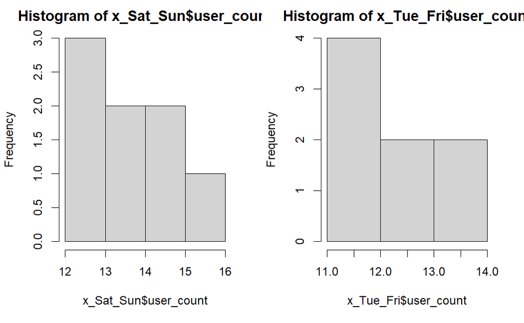

```r
par(mfrow = c(1,2))
hist(x_Sat_Sun$user_count)
hist(x_Tue_Fri$user_count)
```

both histograms are positively skewed  
so it is better to use medians to summarise the differences between number of users on (Sat_sun / Tue_Fri) if the histograms looks different we should use the mean

carrying out Mann-Whitney U test

```r
wilcox.test(Sat_Tue_test_df_csv$user_count~Sat_Tue_test_df_csv$day_type)
```

```
    Wilcoxon rank sum test with continuity correction

data:  Sat_Tue_test_df_csv$user_count by Sat_Tue_test_df_csv$day_type
W = 50.5, p-value = 0.05299
alternative hypothesis: true location shift is not equal to 0
```

Accepting NULL Hypothesis (H0) for Pair 1 (Sat_sun&Tue_Fri)

H0: There is no difference between number of users on Saturday & Sunday compared to the number of users on Tuesday to Friday

p-value = 0.05299 Reporting Mann-Whitney U test

A Mann-Whitney U test showed that there is no significant difference (W = 50.5, p-value = 0.05299) between number of users on Sat_Sun compared to the number of users on Tue_Fri (there is no huge difference in the medians of the two groups)

the median number of users for Sat_Sun group was 14 and Tue_Fri group was 12.5

*Pair 2* (Sat_sun & Monday)

H: There is difference between number of users on Saturday & Sunday compared to the number of users on Monday

H0: There is no difference between number of users on Saturday & Sunday compared to the number of users on Monday

showing summary statistics

```r
Sat_Monday_test_df_csv %>% group_by(day_type)%>% summarise(median_data= median(user_count), iqr=IQR(user_count))
```

| day_type | median_data | iqr |
| --- | --- | --- |
| 1 | 13.5 | 1.75 |
| 3 | 11.5 | 1.50 |

group 3 (Monday) median and iqr for this sample is less than group 1 Sat_Sun

```r
Sat_Monday_test_df_csv
```

| user_count | day_type |
| --- | --- |
| 13 | 1 |
| 16 | 1 |
| 14 | 1 |
| 12 | 1 |
| 10 | 3 |
| 12 | 3 |
| 13 | 3 |
| 11 | 3 |

```r
x_Sat_Sun_2 <- filter(Sat_Monday_test_df_csv,day_type == "1")
x_Monday <- filter(Sat_Monday_test_df_csv,day_type == "3")
```

```r
x_Sat_Sun_2
```

| user_count | day_type |
| --- | --- |
| 13 | 1 |
| 16 | 1 |
| 14 | 1 |
| 12 | 1 |

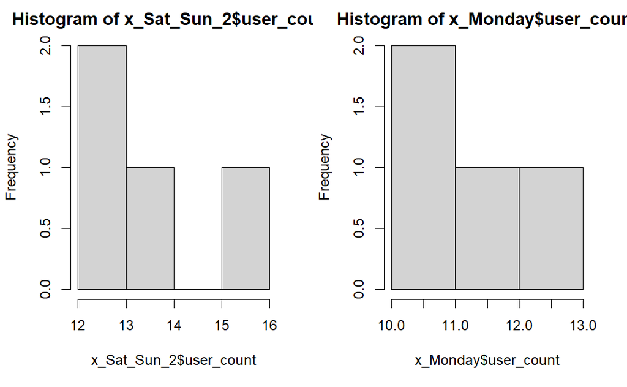

```r
par(mfrow = c(1,2))
hist(x_Sat_Sun_2$user_count)
hist(x_Monday$user_count)
```

both histograms are positively skewed  
so it is better to use medians to summaries the differences between number of users on (Sat_sun / Monday)

if the histograms looks different we should use the mean

carrying out Mann-Whitney U test

```r
wilcox.test(Sat_Monday_test_df_csv$user_count~Sat_Monday_test_df_csv$day_type)
```

```
    Wilcoxon rank sum test with continuity correction

data:  Sat_Monday_test_df_csv$user_count by Sat_Monday_test_df_csv$day_type
W = 14, p-value = 0.1081
alternative hypothesis: true location shift is not equal to 0
```

Accepting NULL Hypothesis (H0) for Pair 2 (Sat_sun&Monday)

H0: There is no difference between number of users on Saturday & Sunday compared to the number of users on Monday

p-value = 0.1081 Reporting Mann-Whitney U test

A Mann-Whitney U test showed that there is no significant difference (W = 14, p-value = 0.1081) between number of users on Sat_Sun compared to the number of users on Monday (there is no huge difference in the medians of the two groups)